# Data from a MC

In this worksheet, we will consider the output of a Markov chain that is stored on a textfile. We will import this data, and do basics statistics to estimate the stationary distribution of corresponding Markov chain.

- Suppose you are given the output of a $100000$ steps of a irreducible and aperiodic finite state Markov chain. Carefully explain how you could estimate the stationary distribution for this Markov chain, and why you estimator is reasonable.
- Import the data from the file markovchain.txt and use this data and your method above to estimate the stationary distribution.
- Any ideas for the transition matrix?

# Solutions

- Since the chain is on a finite state space and irreducible and aperiodic, it has a unique stationary distribution $\pi$, and we know that a version of the law of large numbers gives that for every state $s$, we have

$$\frac{1}{n} \sum_{i=1}^n \mathbf{1}[X_i = s] \to \pi(s).$$
Thus for each state, we simply need to count the number of occurrences and divide by $100000$, to get its approximate probability under $\pi$.

- A quick scan of the file shows there are $4$ states: $1,2,3,4$. With R, we have:

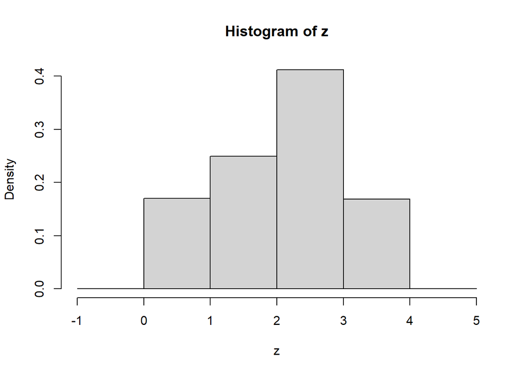

```r
z =read.table("markovchain.txt", sep=",")
z= z[,]

b1 = seq(-1,5, by=1)
hist(z, prob=TRUE, breaks=b1)
```

```r
sum(z==1)/100000
```

```
## [1] 0.17023
```

```r
sum(z==2)/100000
```

```
## [1] 0.24957
```

```r
sum(z==3)/100000
```

```
## [1] 0.41172
```

```r
sum(z==4)/100000
```

```
## [1] 0.16849
```

Next we show how this code might be done in Python; you may need to install the package pandas; if you are running this inside R, you may need to put *py_install(“pandas”)* where you load the *library(reticulate)*.

```python
import pandas as pd
import numpy as np

mydata = pd.read_csv("https://tsoo-math.github.io/ucl3/markovchain.txt", sep =",")

print(mydata)
```

```
##         x
## 1       1
## 2       2
## 3       4
## 4       3
## 5       4
## ...    ..
## 99997   3
## 99998   3
## 99999   2
## 100000  4
## 100001  3
##
## [100001 rows x 1 columns]
```

```python
y = mydata.loc[:, 'x']
print(y)
```

```
## 1         1
## 2         2
## 3         4
## 4         3
## 5         4
##          ..
## 99997     3
## 99998     3
## 99999     2
## 100000    4
## 100001    3
## Name: x, Length: 100001, dtype: int64
```

```python
print(np.mean(y==1))
```

```
## 0.17022829771702283
```

```python
print(np.mean(y==2))
```

```
## 0.24956750432495675
```

```python
print(np.mean(y==3))
```

```
## 0.4117158828411716
```

```python
print(np.mean(y==4))
```

```
## 0.16848831511684884
```

# Endnotes

- Version: 23 October 2022
- [Rmd Source](https://tsoo-math.github.io/ucl3/week9-2022-inclass-sols.Rmd)